# Biost 540: Homework 1

Department of Biostatistics @ University of Washington

Alejandro Hernandez

Due Thursday 11, April 2024

## Problem 1

The Iris dataset, which Ronald Fisher presented in his 1936 paper “The use of multiple measurements in taxonomic problems,” comprises three species of plants (setosa, virginica, and versicolor) with four measured features for each sample.

```r
# load Iris data
data(iris)

# dim(iris)
# names(iris)
# head(iris)
# table(iris$Species)
```

### 1a)

Please calculate the number, average petal length, and average petal width for each species.

```r
# summarize average petal measurements for each species
iris %>%
  group_by(Species) %>%
  summarise(
    n = length(Species),
    Average.petal.length = mean(Petal.Length),
    Average.petal.width = mean(Petal.Width)) %>%
  knitr::kable()
```

| Species | n | Average.petal.length | Average.petal.width |
| --- | --- | --- | --- |
| setosa | 50 | 1.462 | 0.246 |
| versicolor | 50 | 4.260 | 1.326 |
| virginica | 50 | 5.552 | 2.026 |

### 1b)

Please draw a scatterplot using ggplot for `Sepal.Length` and `Sepal.Width`. And please assign different colors for different species.

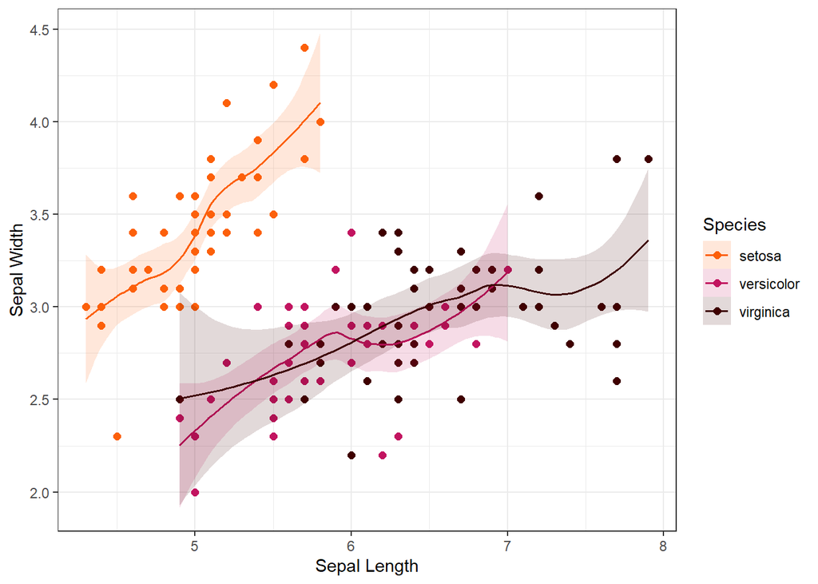

Figure 1. Scatterplot of Sepal Measures by Species

```r
# color selection
colors <- c("#FC600A", # dark orange
            "#C21460", # dark pink
            "#3F0000") # darker red

# plot sepal measurements for each species
iris %>%
  ggplot(aes(x=Sepal.Length, y=Sepal.Width, color=Species, fill=Species)) +
  geom_point(size=2) +
  geom_smooth(alpha=0.15, lwd=.7) +
  xlab("Sepal Length") + ylab("Sepal Width") +
  scale_color_manual(values=colors) +
  scale_fill_manual(values=colors) +
  theme_bw()
```

## Problem 2

```r
data(WorldPhones)

# dim(WorldPhones)
WorldPhones
```

```
##      N.Amer Europe Asia S.Amer Oceania Africa Mid.Amer
## 1951  45939  21574 2876   1815    1646     89      555
## 1956  60423  29990 4708   2568    2366   1411      733
## 1957  64721  32510 5230   2695    2526   1546      773
## 1958  68484  35218 6662   2845    2691   1663      836
## 1959  71799  37598 6856   3000    2868   1769      911
## 1960  76036  40341 8220   3145    3054   1905     1008
## 1961  79831  43173 9053   3338    3224   2005     1076
```

### 2a)

Please create a new column called `year` using the rownames of the data. Convert the data into long table such that there are 3 columns in total including year, region and number.

```r
# define new `year` column
WorldPhones <- WorldPhones %>%
  data.frame(.) %>%
  mutate(year = rownames(.))

WorldPhones %>%
  pivot_longer(cols = c("N.Amer", "Europe", "Asia", "S.Amer", "Oceania", "Africa", "Mid.Amer"),
               names_to = "region",
               values_to = "n.telephones")
```

```
## # A tibble: 49 × 3
##    year  region   n.telephones
##    <chr> <chr>           <dbl>
##  1 1951  N.Amer          45939
##  2 1951  Europe          21574
##  3 1951  Asia             2876
##  4 1951  S.Amer           1815
##  5 1951  Oceania          1646
##  6 1951  Africa             89
##  7 1951  Mid.Amer          555
##  8 1956  N.Amer          60423
##  9 1956  Europe          29990
## 10 1956  Asia             4708
## # ℹ 39 more rows
```

## Problem 3

The Treatment of Lead-Exposed Children (TLC) trial was a placebo-controlled, randomized study of succimer (a chelating agent) in children with bloodlead levels of 20-44 micrograms/dL. These data consist of four repeated measurements of blood lead levels obtained at baseline (or week 0), week 1, week 4, and week 6 on 100 children who were randomly assigned to chelation treatment with succimer or placebo.

Each row of the data set contains the following 6 variables: ID, Treatment Group, Lead Level Week 0, Lead Level Week 1, Lead Level Week 4, Lead Level Week 6.

```r
# load lead exposure study data
tlc <- read.csv("data/tlc.csv")[,-1]

tlc <- tlc %>%
  mutate(tx = as.factor(tx)) %>%
  rename(week.0=y0,
         week.1=y1,
         week.4=y4,
         week.6=y6)

levels(tlc$tx) <- c("Treatment", "Placebo")
```

### 3a)

Transform the data into long format and produce spaghetti plots illustrating the progression in lead level. Facet the plot by treatment group; be sure to label axes appropriately with units. Hint: the functions `pivot_longer` (with argument names_prefix) and `facet_wrap` will be useful to you.

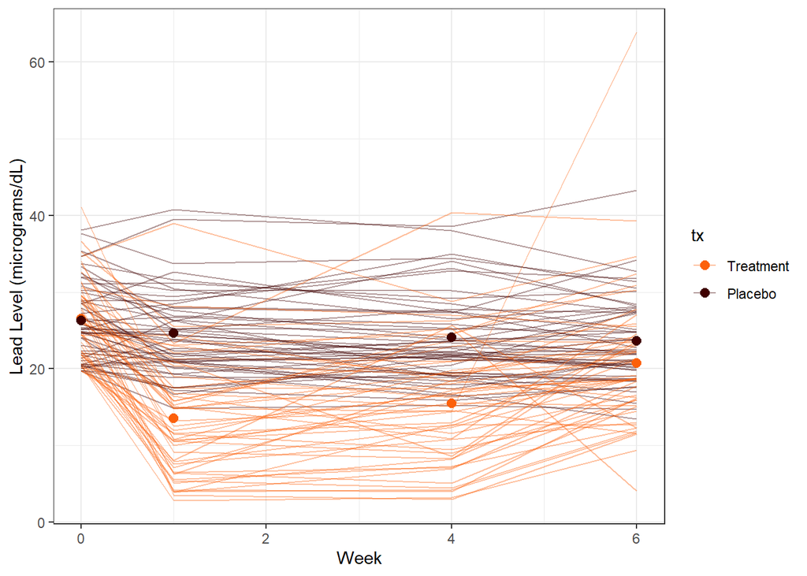

Lead levels and averages by week and treatment group

```r
# transform data to long format
tlc_long <- tlc %>%
  pivot_longer(cols = starts_with("week."),
               names_to = "week",
               names_prefix = "week.",
               values_to = "lead.level") %>%
  mutate_at(c("id", "week"), as.integer)

# plot of lead levels and averages over time, by treatment
gg <- tlc_long %>%
  ggplot(aes(x=week, y=lead.level)) +
  geom_line(aes(group=id, color=tx), alpha=0.4) +
  geom_point(data = tlc_long %>%
               group_by(tx, week) %>%
               summarise(mean=mean(lead.level)),
             aes(x=week, y=mean, color=tx), size=2.5) +
  xlab("Week") + ylab("Lead Level (micrograms/dL)") +
  scale_color_manual(values=colors[c(1,3)]) +
  theme_bw()

gg                        # treatment groups overlayed
```

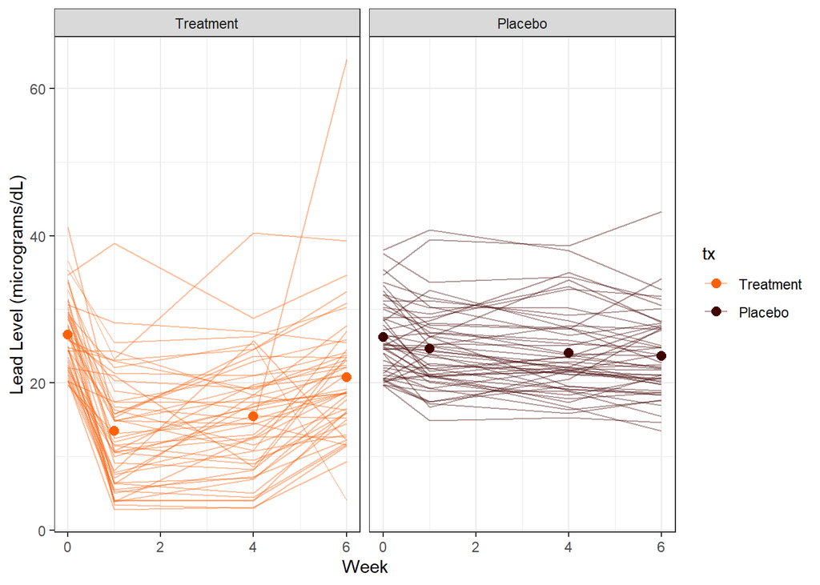

Lead levels and averages by week and treatment group

```r
gg + facet_wrap(vars(tx)) # treatment group separated
```

### 3b)

Compute the Pearson correlation matrix between outcomes at different time points.

```r
# correlation matrix
tlc %>%
  select(starts_with("week.")) %>%
  cor %>%
  round(2)
```

```
##        week.0 week.1 week.4 week.6
## week.0   1.00   0.42   0.47   0.56
## week.1   0.42   1.00   0.84   0.56
## week.4   0.47   0.84   1.00   0.58
## week.6   0.56   0.56   0.58   1.00
```

### 3c)

Suppose you were interested in comparing the mean difference in lead levels between treatment and control groups 6 weeks after treatment provision. Using a linear model, compare the lead levels between treatment groups at the 6 week time point. Provide and describe a point estimate for the treatment effect along with the standard error. Does treatment have a significant effect on the Week 6 lead levels at significance level 0.05?

```r
# fit linear model of week 6 level from treatment group
mod_post <- rigr::regress("mean", week.6 ~ tx, data = tlc)

coef(mod_post)[,c("Estimate","Robust SE","Pr(>|t|)")] %>% round(., 3)
```

```
##             Estimate Robust SE Pr(>|t|)
## (Intercept)   20.762     1.308    0.000
## txPlacebo      2.884     1.532    0.063
```

### 3d)

Suppose we adopt an approach to analyze the change scores from week 0 to week 6. Using a linear model, compare the change in lead levels from week 0 to week 6 between treatment groups. Provide and describe a point estimate for the treatment effect along with the standard error. Does your conclusion from part C change?

```r
# fit linear model of change in lead level from treatment group
mod_change <- tlc %>%
  mutate(change = week.6 - week.0) %>%
  rigr::regress("mean", change ~ tx, data = .)

coef(mod_change)[,c("Estimate","Robust SE","Pr(>|t|)")] %>% round(., 3)
```

```
##             Estimate Robust SE Pr(>|t|)
## (Intercept)   -5.778     1.138    0.000
## txPlacebo      3.152     1.257    0.014
```

### 3e)

Suppose we wish to use an ANCOVA model to evaluate the effect of treatment on Week 6 lead levels adjusting for the baseline lead level. Reinterpret the treatment effect and provide an estimate of the standard error. Does your conclusion differ from part C? Hint: ANCOVA is a linear model which adjusts for the baseline outcome as covariate.

```r
# fit linear model of week 6 level from treatment group and week 0 level
mod_ancova <- rigr::regress("mean", week.6 ~ tx + week.0, data = tlc)

coef(mod_ancova)[,c("Estimate","Robust SE","Pr(>|t|)")] %>% round(., 3)
```

```
##             Estimate Robust SE Pr(>|t|)
## (Intercept)   -2.596     3.445    0.453
## txPlacebo      3.120     1.238    0.013
## week.0         0.880     0.151    0.000
```

### 3f)

Plot the standard errors of each of the models fit in parts C-E. How does incorporating knowledge of the baseline response impact the precision or power of your inference on the treatment effect at 6 weeks?

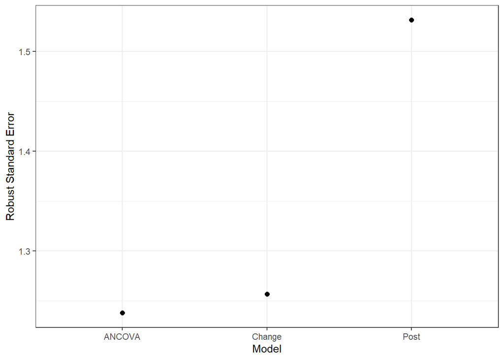

```r
# plot standard errors of each model
data.frame(
  model = c("Post", "Change", "ANCOVA"),
  robust.sd = c(coef(mod_post)["txPlacebo","Robust SE"],
                coef(mod_change)["txPlacebo","Robust SE"],
                coef(mod_ancova)["txPlacebo","Robust SE"])) %>%
  ggplot(data = ., aes(x = model, y = robust.sd)) +
    geom_point(size = 2) +
    xlab("Model") + ylab("Robust Standard Error") + theme_bw()
```

## Problem 4

The Six Cities Study of Air Pollution and Health was a longitudinal study designed to characterize lung growth as measured by changes in pulmonary function in children and adolescents, and the factors that influence lung function growth. A cohort of 13,379 children born on or after 1967 was enrolled in six communities across the U.S.: Watertown (Massachusetts), Kingston and Harriman (Tennessee), a section of St. Louis (Missouri), Steubenville (Ohio), Portage (Wisconsin), and Topeka (Kansas). Most children were enrolled in the first or second grade (between the ages of six and seven) and measurements of study participants were obtained annually until graduation from high school or loss to follow-up. At each annual examination, spirometry, the measurement of pulmonary function, was performed and a respiratory health questionnaire was completed by a parent or guardian.

The dataset contains a subset of the pulmonary function data collected in the Six Cities Study. The data consist of all measurements of FEV1, height and age obtained from a randomly selected subset of the female participants living in Topeka, Kansas. The random sample consists of 300 girls, with a minimum of one and a maximum of twelve observations over time. The variables included in the dataset are `Subject ID`, `Height`, `Age`, `Initial Height`, `Initial Age`, and `Log(FEV1)` (a spirometry measure of lung function).

```r
# load FEV data
fev <- read.csv("data/Topeka-2.csv")
```

## 4a)

Produce a summary (e.g., mean) of the initial height, initial age, and initial log(FEV1). Hint: you will create the initial logFEV1 variable using mutate, selecting the logFEV1 variable when age==age0. You will also need to use the function select and distinct functions to select a single entry per participant, such that the mean is not calculated over repeated measures.

```r
# summarize number of times an individual was measured and their average
fev %>%
  group_by(id) %>%
  summarise(n.measures = length(logFEV1),
            mean.logFEV = min(logFEV1))
```

```
## # A tibble: 300 × 3
##       id n.measures mean.logFEV
##    <int>      <int>       <dbl>
##  1     1          7      0.215
##  2     2          8      0.307
##  3     3          9      0.385
##  4     4         10      0.0583
##  5     5          7      0.0296
##  6     6         11      0.262
##  7     7          7     -0.0305
##  8     8          9      0.270
##  9     9          9      0
## 10    10         10      0.148
## # ℹ 290 more rows
```

```r
# calculate averages of initial measures
# gather initial measures
initial.measures <- fev %>%
  group_by(id, height0, age0) %>%
  summarize(n = length(height0),
            logFEV1.0 = logFEV1[1]) %>%
  select(id, n, everything())

# average initial measures
initial.measures %>%
  ungroup(id) %>%
  select(height0, age0, logFEV1.0) %>%
  colMeans %>%
  round(., 3)
```

```
##   height0      age0 logFEV1.0
##     1.289     8.297     0.383
```

**End of document.**